# Fort Pickens State Park Aquatic Preserve

**Sampling locations by Program:**

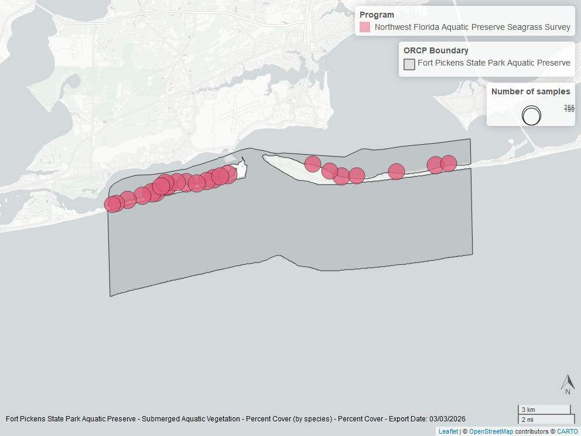

Map showing SAV sampling sites within the boundaries of *Fort Pickens State Park Aquatic Preserve*. The point size reflects the number of samples at a given sampling site.

Program Information for Submerged Aquatic Vegetation

| ProgramID | N-Data | YearMin | YearMax | method | Sample Locations |
| --- | --- | --- | --- | --- | --- |
| 4065 | 5413 | 2016 | 2025 | Braun Blanquet | 24 |

**Program names:**

*4065* - Northwest Florida Aquatic Preserve Seagrass Survey<sup>4</sup>

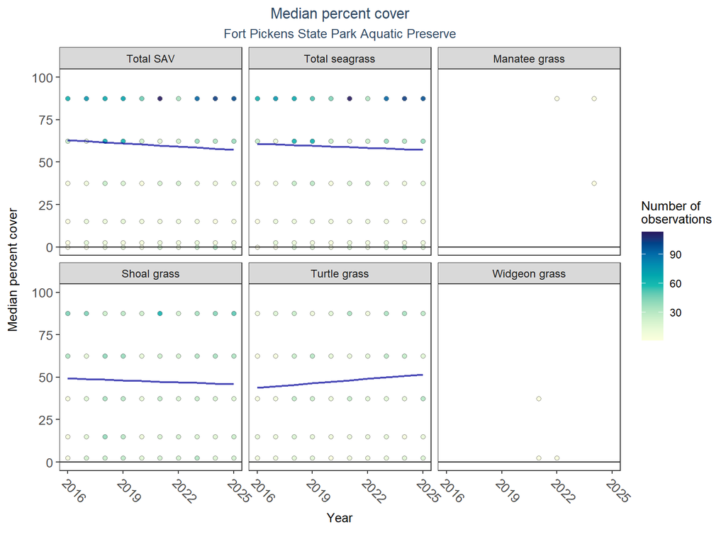

Scatter plots of median percent cover of submerged aquatic vegetation over time by group. Plots for time series that included five or more years of observations show the estimated trend as a blue line.

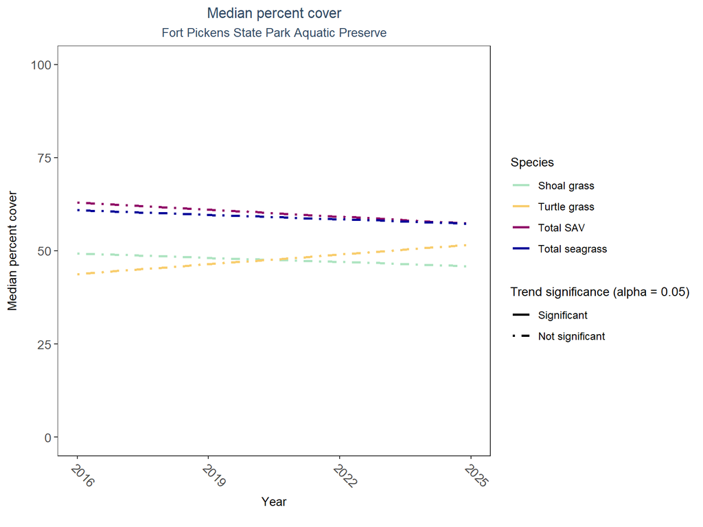

Trend lines of median percent cover of submerged aquatic vegetation over time for species that had five or more years of observations. Line type represents significance (solid) or non-significance (dashed) of the trends.

Percent Cover Trend Analysis for Fort Pickens State Park Aquatic Preserve

| Species | Statistical Trend | Period of Record | LME Intercept | LME Slope | P |
| --- | --- | --- | --- | --- | --- |
| Shoal grass | No detectable trend | 2016 - 2025 | 57.57890 | -0.3767541 | 0.2953574 |
| Widgeon grass | Insufficient data | - | - | - | - |
| Manatee grass | Insufficient data | - | - | - | - |
| Turtle grass | No detectable trend | 2016 - 2025 | 24.56426 | 0.8736583 | 0.1413376 |
| Total SAV | No detectable trend | 2016 - 2025 | 76.78994 | -0.6282133 | 0.2198503 |
| Total seagrass | No detectable trend | 2016 - 2025 | 69.85539 | -0.4064261 | 0.4461533 |

Total SAV, total seagrass, shoal grass, and turtle grass showed no detectable change in percent cover. Trends in percent cover could not be evaluated for manatee grass and widgeon grass due to insufficient data.

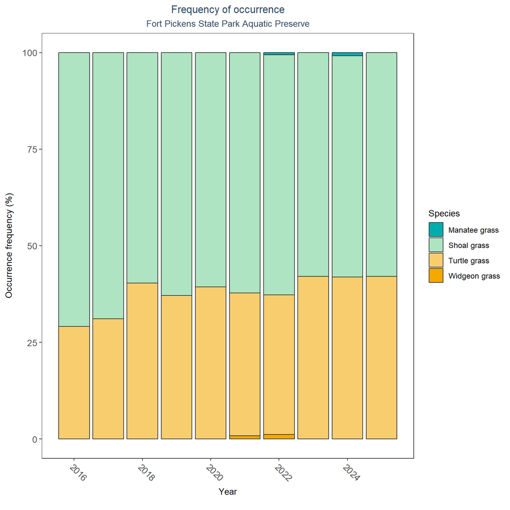

Bar plot of submerged aquatic vegetation species occurrence frequency over time by group.

## SAV Water Column Analysis

The following parameters are available for Fort Pickens State Park Aquatic Preserve within the SAV_WC_Report:

- Chlorophyll a
- Dissolved Oxygen
- Dissolved Oxygen Saturation
- pH
- Salinity
- Secchi Depth
- Water Temperature
- Total Nitrogen
- Total Suspended Solids
- Turbidity
- Colored Disolved Organic Matter
- Chlorophyll a
- Dissolved Oxygen
- Dissolved Oxygen Saturation
- pH
- Salinity
- Secchi Depth
- Water Temperature
- Total Nitrogen
- Total Suspended Solids
- Turbidity

Access the reports here: DRAFT_SAV_WC_Report.pdf

# Species list

| Digenea simplex<sup>1</sup> | Ruppia maritima<sup>1</sup> | Total macroalgae<sup>1</sup> |
| --- | --- | --- |
| Halodule wrightii<sup>1</sup> | Sargassum sp.<sup>1</sup> | Total SAV<sup>1</sup> |
| No grass in quadrat<sup>1</sup> | Syringodium filiforme<sup>1</sup> | Total seagrass<sup>1</sup> |
| Polysiphonia sp.<sup>1</sup> | Thalassia testudinum<sup>1</sup> | Digenea simplex<sup>1</sup> |

1 - Submerged Aquatic Vegetation

# References

1.

Florida Department of Environmental Protection (DEP). [Florida STORET / WIN](https://data.florida-seacar.org/programs/details/5002). (2024).

2.

U.S. Environmental Protection Agency (EPA); Gulf Ecology Division. [Pensacola Bay Water Quality Monitoring Program](https://data.florida-seacar.org/programs/details/505). (2016).

3.

University of Florida (UF); Institute of Food and Agricultural Sciences. [Florida LAKEWATCH Program](https://data.florida-seacar.org/programs/details/514). (2024).

4.

Florida Department of Environmental Protection (DEP); Office of Resilience and Coastal Protection (RCP); Northwest Aquatic Preserves. [Northwest Florida Aquatic Preserve Seagrass Survey](https://data.florida-seacar.org/programs/details/4065). (2024).

5.

Florida Fish and Wildlife Conservation Commission (FWC). [Fisheries-Independent Monitoring (FIM) Program](https://data.florida-seacar.org/programs/details/69). (2022).

6.

Florida Fish and Wildlife Conservation Commission (FWC); Florida Fish and Wildlife Research Institute (FWRI). [Harmful Algal Bloom Marine Observation Network](https://data.florida-seacar.org/programs/details/95). (2018).

7.

Gulf States Marine Fisheries Commission. [Southeast Area Monitoring and Assessment Program (SEAMAP) - Gulf of Mexico Fall & Summer Shrimp/Groundfish Survey](https://data.florida-seacar.org/programs/details/60). (2016).

8.

U.S. Environmental Protection Agency (EPA); Office of Research and Development. [Environmental Monitoring Assessment Program](https://data.florida-seacar.org/programs/details/115). (2004).

9.

U.S. Environmental Protection Agency (EPA); Office of Water; National Oceanic and Atmospheric Administration (NOAA); U.S. Geological Survey (USGS); U.S. Fish and Wildlife Service (USFWS); National Estuary Program (NEP); coastal states. [National Aquatic Resource Surveys, National Coastal Condition Assessment](https://data.florida-seacar.org/programs/details/118). (2021).

10.

U.S. Environmental Protection Agency (EPA). [EPA STOrage and RETrieval Data Warehouse (STORET)/WQX](https://data.florida-seacar.org/programs/details/103). (2023).